# Nicho y MDE 2

Horacio Samaniego (horacio.samaniego@gmail.com)

2025-06-05

# Ayudantía 3: Modelos de Nicho

**Parte 2:** Esta parte de la ayudantía está destinada a la descarga de variables climáticas y la preparación de los datos para el análisis de nicho climático.

## 0: Setup: Cargar paquetes, configurar el entorno y directorio de trabajo.

Del ejercicio pasado, tenemos que importar el set de datos y volver a darle coordenadas

```r
datos <- st_read("tricahue.gpkg") |>
  st_transform(crs = 'EPSG:4326') |>
  dplyr::select(scientificName, grupo)
```

## 1: Nicho climático

Vamos a buscar cuáles son las condiciones climáticas en que están estos registros para generar asi, una definición (gruesa) del nicho climático para Tricahue.

Usaremos los datos de Worldclim, que se encuentran documentados [aquí](https://www.worldclim.org). Sólo usaremos las variables bioclimáticas, en este ejemplo, pero debes complementar esto con variables de precipitaciones, temperatura y radiación solar si fuera necesario.

- Ojo: La función `worldclim_country()` de la librería `geodata` permite descargar directamente desde worldclim los datos bioclimáticos por paises. Worlclim ofrece sus datos en 4 resoluciones espaciales diferentes; de 30 segundos (0,93 x 0,93 = 0,86 km2 en el ecuador) a 2,5, 5 y 10 minutos (18,6 x 18,6 = 344 km2 en el ecuador). Los datos originales tenían una resolución de 30 segundos. También ofrece datos climáticos de distintas proyecciones de cambio climático futuro (CMIP5) del modelo ‘AC’ para el año 2070, por ejemplo.

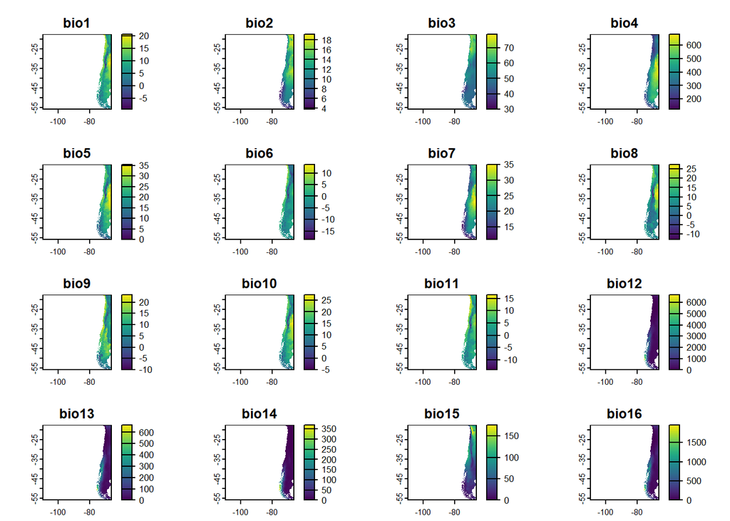

```r
Bioclim <- geodata::worldclim_country(c("Chile","Argentina"),
                             var=c("bio"), res=0.5, path=getwd())

names(Bioclim) <- sapply(strsplit(names(Bioclim), split='30s_', fixed=TRUE), function(x) (x[2])) # renombra columnas
names(Bioclim) <- sapply(gsub('_','',names(Bioclim)), function(x) (x))


plot(Bioclim)
```

Si quieres ver una sola capa y un poco mas grande

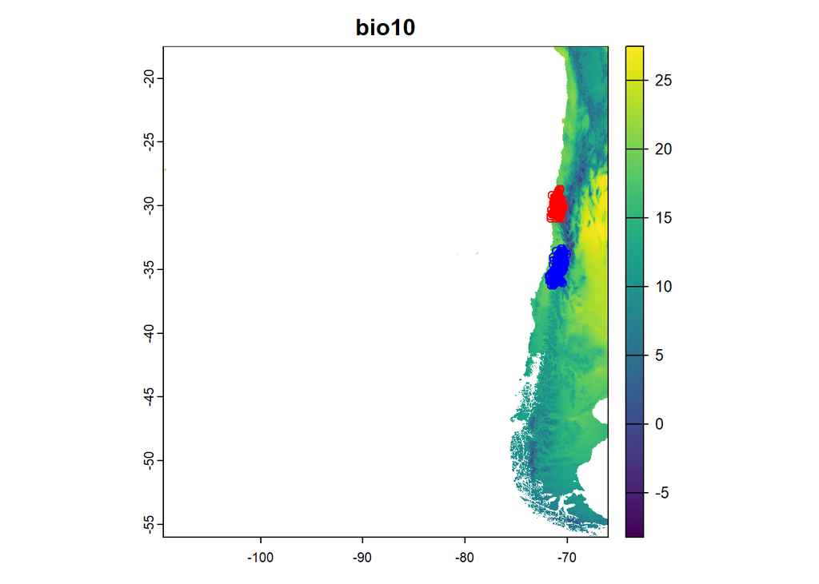

```r
capa = 'bio10'
plot(Bioclim[[capa]], main = capa)
plot(datos %>% filter(grupo == 'Norte'), add = TRUE, col = 'red')
plot(datos %>% filter(grupo == 'Sur'),   add = TRUE, col = 'blue')
```

Al igual que es posible descargar los datos actuales de clima, tambien podemos descargar datos modelados a futuro

```r
# Bioclim_futuro <- geodata::cmip6_world(
#   var = "bio",                # Variables bioclimáticas
#   res = 0.5,                  # Resolución (en minutos: 10, 5, 2.5)
#   ssp = "ssp245",             # Escenario: ssp126, ssp245, ssp370, ssp585
#   model = "BCC-CSM2-MR",      # Modelo climático (hay muchos disponibles)
#   time = "2041-2060",         # Periodo
#   path = getwd()              # Carpeta de descarga
# )
#
# names(Bioclim_futuro) <- sapply(strsplit(names(Bioclim_futuro), split='30s_', fixed=TRUE), function(x) (x[2])) # renombra columnas
# names(Bioclim_futuro) <- sapply(gsub('_','',names(Bioclim_futuro)), function(x) (x))
#
# plot(Bioclim_futuro)
```

## 2: Clima en registros de *C. patagonus*

Para extraer los datos bioclimáticos en las coordenadas geográficas, debemos consultar los pixeles de los rasters bioclimáticos donde existen ocurrencias en muestra base de datos.

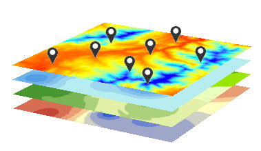

Ejemplo de consulta de valores de raster en coordenadas

Con eso generamos una tabla con las variables climáticas en cada una de las coordenadas en que tenemos registros.

```r
# Dividir datos
S = datos %>% filter(grupo == 'Sur')
N = datos %>% filter(grupo == 'Norte')

# extraer los valores del raster Bioclim para los puntos de ocurrencia
clima <- terra::extract(Bioclim, st_transform(datos,'EPSG:4326'))
climaS <- terra::extract(Bioclim, st_transform(S,'EPSG:4326'))
climaN <- terra::extract(Bioclim, st_transform(N,'EPSG:4326'))

# sacar primera columna (id)
clima <- clima[,-1]
climaN <- climaN[,-1]
climaS <- climaS[,-1]

# ver resumen
clima %>% glimpse()
```

```
## Rows: 1,709
## Columns: 19
## $ bio1  <dbl> 10.787500, 14.279167, 12.775000, 15.100000, 12.620833, 15.345834…
## $ bio2  <dbl> 13.841666, 11.008333, 12.783334, 8.083333, 12.858334, 12.258333,…
## $ bio3  <dbl> 49.79017, 56.74399, 48.79135, 52.15054, 49.26564, 46.96679, 50.3…
## $ bio4  <dbl> 517.9379, 317.6366, 491.5352, 279.1220, 483.2393, 500.9512, 462.…
## $ bio5  <dbl> 26.9, 24.3, 27.9, 23.0, 27.9, 30.4, 27.0, 25.1, 23.7, 24.3, 30.5…
## $ bio6  <dbl> -0.9, 4.9, 1.7, 7.5, 1.8, 4.3, 1.4, 5.3, 5.7, 4.9, 5.0, 4.0, 5.4…
## $ bio7  <dbl> 27.8, 19.4, 26.2, 15.5, 26.1, 26.1, 25.6, 19.8, 18.0, 19.4, 25.5…
## $ bio8  <dbl> 5.266666, 10.483334, 7.500000, 11.800000, 7.533333, 9.916667, 7.…
## $ bio9  <dbl> 17.33333, 17.98333, 18.98333, 18.66667, 18.80000, 21.08333, 17.2…
## $ bio10 <dbl> 17.33333, 18.28333, 18.98333, 18.66667, 18.80000, 21.60000, 17.8…
## $ bio11 <dbl> 4.483333, 10.483334, 6.866667, 11.800000, 6.800000, 9.350000, 6.…
## $ bio12 <dbl> 845, 100, 794, 90, 928, 725, 1205, 126, 31, 100, 648, 66, 79, 83…
## $ bio13 <dbl> 182, 35, 188, 29, 196, 176, 249, 47, 10, 35, 164, 23, 28, 180, 1…
## $ bio14 <dbl> 13, 0, 8, 0, 12, 4, 17, 0, 0, 0, 2, 0, 0, 12, 12, 3, 0, 1, 10, 1…
## $ bio15 <dbl> 86.22415, 122.44608, 95.60803, 118.02080, 87.01364, 103.99663, 8…
## $ bio16 <dbl> 480, 77, 479, 68, 526, 471, 689, 97, 25, 77, 442, 50, 60, 477, 5…
## $ bio17 <dbl> 43, 0, 28, 0, 41, 16, 58, 0, 0, 0, 10, 0, 0, 42, 41, 15, 0, 8, 3…
## $ bio18 <dbl> 43, 0, 28, 0, 41, 17, 60, 0, 0, 0, 11, 0, 0, 42, 41, 20, 0, 11, …
## $ bio19 <dbl> 452, 77, 457, 68, 491, 433, 634, 97, 25, 77, 392, 50, 60, 453, 4…
```

Vemos la tabla con los datos bioclimáticos para cada registro. *(filas = primero 15 registros)*

| bio1 | bio2 | bio3 | bio4 | bio5 | bio6 | bio7 | bio8 | bio9 | bio10 | bio11 | bio12 | bio13 | bio14 | bio15 | bio16 | bio17 | bio18 | bio19 |
| --- | --- | --- | --- | --- | --- | --- | --- | --- | --- | --- | --- | --- | --- | --- | --- | --- | --- | --- |
| 10.78750 | 13.841666 | 49.79017 | 517.9379 | 26.9 | -0.9 | 27.8 | 5.266666 | 17.33333 | 17.33333 | 4.483333 | 845 | 182 | 13 | 86.22415 | 480 | 43 | 43 | 452 |
| 14.27917 | 11.008333 | 56.74399 | 317.6366 | 24.3 | 4.9 | 19.4 | 10.483334 | 17.98333 | 18.28333 | 10.483334 | 100 | 35 | 0 | 122.44608 | 77 | 0 | 0 | 77 |
| 12.77500 | 12.783334 | 48.79135 | 491.5352 | 27.9 | 1.7 | 26.2 | 7.500000 | 18.98333 | 18.98333 | 6.866667 | 794 | 188 | 8 | 95.60803 | 479 | 28 | 28 | 457 |
| 15.10000 | 8.083333 | 52.15054 | 279.1220 | 23.0 | 7.5 | 15.5 | 11.800000 | 18.66667 | 18.66667 | 11.800000 | 90 | 29 | 0 | 118.02080 | 68 | 0 | 0 | 68 |
| 12.62083 | 12.858334 | 49.26564 | 483.2393 | 27.9 | 1.8 | 26.1 | 7.533333 | 18.80000 | 18.80000 | 6.800000 | 928 | 196 | 12 | 87.01364 | 526 | 41 | 41 | 491 |
| 15.34583 | 12.258333 | 46.96679 | 500.9512 | 30.4 | 4.3 | 26.1 | 9.916667 | 21.08333 | 21.60000 | 9.350000 | 725 | 176 | 4 | 103.99663 | 471 | 16 | 17 | 433 |
| 11.91667 | 12.900000 | 50.39062 | 462.5637 | 27.0 | 1.4 | 25.6 | 7.100000 | 17.23333 | 17.88333 | 6.383333 | 1205 | 249 | 17 | 86.75797 | 689 | 58 | 60 | 634 |
| 14.82917 | 10.941667 | 55.26094 | 339.8493 | 25.1 | 5.3 | 19.8 | 10.766666 | 18.78333 | 19.10000 | 10.766666 | 126 | 47 | 0 | 127.98759 | 97 | 0 | 0 | 97 |
| 14.35000 | 10.716667 | 59.53703 | 276.0599 | 23.7 | 5.7 | 18.0 | 11.083333 | 17.66667 | 17.88333 | 11.083333 | 31 | 10 | 0 | 103.36774 | 25 | 0 | 0 | 25 |
| 14.27917 | 11.008333 | 56.74399 | 317.6366 | 24.3 | 4.9 | 19.4 | 10.483334 | 17.98333 | 18.28333 | 10.483334 | 100 | 35 | 0 | 122.44608 | 77 | 0 | 0 | 77 |
| 15.93750 | 12.091666 | 47.41830 | 489.1511 | 30.5 | 5.0 | 25.5 | 10.516667 | 21.46667 | 22.03333 | 10.050000 | 648 | 164 | 2 | 109.61856 | 442 | 10 | 11 | 392 |
| 12.87500 | 11.166667 | 59.71479 | 288.3220 | 22.7 | 4.0 | 18.7 | 9.483334 | 16.25000 | 16.55000 | 9.483334 | 66 | 23 | 0 | 115.96590 | 50 | 0 | 0 | 50 |
| 14.70833 | 11.033334 | 57.46528 | 313.9110 | 24.6 | 5.4 | 19.2 | 10.933333 | 18.65000 | 18.65000 | 10.933333 | 79 | 28 | 0 | 116.93127 | 60 | 0 | 0 | 60 |
| 10.14583 | 13.791667 | 49.96981 | 515.1587 | 26.1 | -1.5 | 27.6 | 4.666667 | 16.63333 | 16.63333 | 3.866667 | 839 | 180 | 12 | 86.68415 | 477 | 42 | 42 | 453 |
| 12.62500 | 12.883333 | 48.98606 | 490.2202 | 28.0 | 1.7 | 26.3 | 7.416666 | 18.88333 | 18.88333 | 6.716667 | 917 | 196 | 12 | 87.47552 | 523 | 41 | 41 | 487 |

Ahora, a qué corresponde bio1, bio2, etc…??

Veamos, por una parte, qué son estas variables:

[interactive chart not shown]

Por otra parte, la inspección de la tabla muestra que sólo tiene los valores bioclimáticos. Necesitamos, ciertamente, asociar los registros y probablemente otros datos climáticos como temperatura, precipitaciones, radiación, por ejemplo.

Pero miremos primero cómo se relacionan los valores bioclimáticos recuperados para GBIF tiene registros de *C. patagonus* en Chile.

### Selección de vaiables (bioclimáticas)

Sabemos que las variables bioclimáticas son variables derivadas de la variables de clima. Por lo tanto, han de tener **fuertes correlaciones entre ellas**. La pregunta es cuales elegir y minimizar asi, esta correlación espuria que sólo incrementará el ajuste del modelo de forma artificial.

- [Ver aqui](https://www.worldclim.org/data/bioclim.html) la descripción de las variable bioclimáticas de worldclim.

A continuación se describen las 19 variables bioclimáticas:

- bio1 = Temperatura media anual
- bio2 = amplitud diurna media (media de la temperatura máxima y mínima)
- bio3 = Isotermia (bio2/bio7) (* 100)
- bio4 = Estacionalidad de la temperatura (desviación típica *100)
- bio5 = Temperatura máxima del mes más cálido
- bio6 = Temperatura mínima del mes más frío
- bio7 = Rango anual de temperaturas (bio5-bio6)
- bio8 = Temperatura media del trimestre más húmedo
- bio9 = Temperatura media del trimestre más seco
- bio10 = Temperatura media del trimestre más cálido
- bio11 = Temperatura media del trimestre más frío
- bio12 = Precipitación total (anual)
- bio13 = Precipitación del mes más húmedo
- bio14 = Precipitación del mes más seco
- bio15 = Estacionalidad de las precipitaciones (coeficiente de variación)
- bio16 = Precipitación del trimestre más húmedo
- bio17 = Precipitaciones del trimestre más seco
- bio18 = Precipitaciones del trimestre más cálido
- bio19 = Precipitaciones del trimestre más frío

Buscamos comprender cuáles variables bioclimáticas son significativamente relevantes para describir, y predecir, la distribución de la especie. Esto significa que debemos poder tener una variables que representan, en realidad, un mismo aspecto del clima a la hora de generar una predicción.

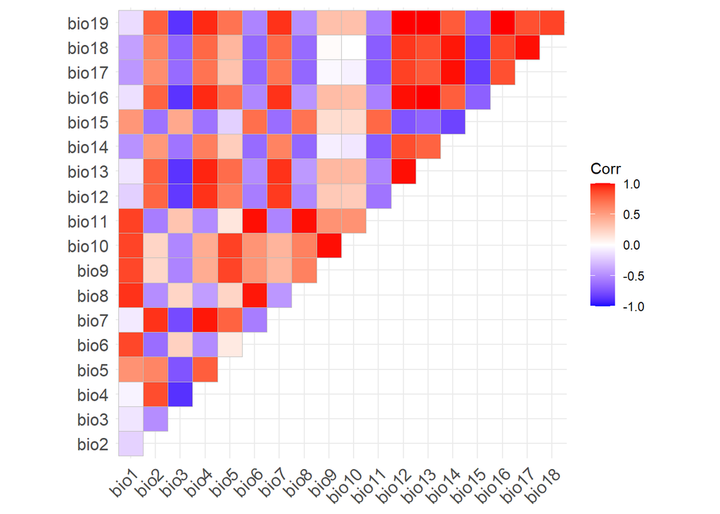

```r
# install.packages("ggcorrplot")
# library(ggcorrplot)

corr <- cor(clima,use = "pairwise")

ggcorrplot::ggcorrplot(corr, method='square',pch=2,show.diag = FALSE, type = "upper", ggtheme = theme_minimal())
```

Hacemos algunas modificaciones al grafico de correlaci[on para mejorar la legibilidad y seleccionamos algunas variables de *Bioclim* que muestren baja correlación (cercana a 0, no negativa!).

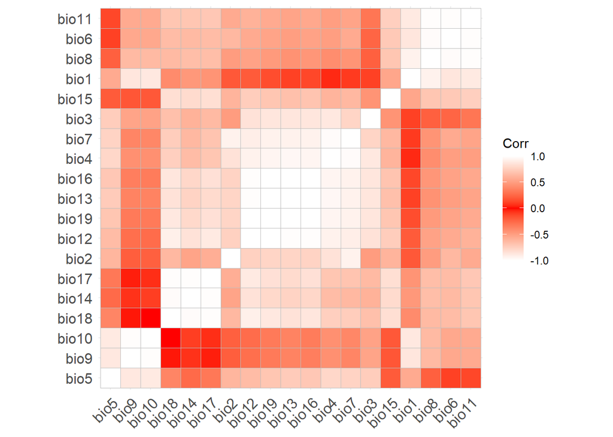

```r
ggcorrplot::ggcorrplot(corr, method='square',pch=2,show.diag = T, type = "full", ggtheme = theme_minimal(), hc.order = TRUE, colors = c("white", "red", "white"))
```

(son todas de temperatura?…. mmmh sospechoso. Creo que será importante considerar directamente las variables climáticas.)

```r
## ejemplo con algunas variables... que no son las correctas, pero muestra el procedimiento
var_ambientales <- clima|>
  dplyr::select(bio1,bio5,bio9,bio10)

rm(clima) # borramos para aliviar la memoria del compu!
```

## 3: Guardamos los datos

Necesitamos guardar algunos de los objetos creados para usarlos en otra sesion.

```r
# escribir un raster al disco como .tif
writeRaster(Bioclim, "Bioclim_raster.tif", overwrite=TRUE)
```

```
## |---------|---------|---------|---------|=========================================
```

```r
# Variables ambientales seleccionadas
write.csv(var_ambientales,"var_ambientales.csv")

# Variables por grupo (opcional)
# write.csv(Clima,"clima.csv")
# write.csv(ClimaN,"climaN.csv")
# write.csv(ClimaS,"climaS.csv")
```

## 4: Resumen

En esta sesion perparamos los datos para el análisis de nicho climático